# HospitalTSF

```python
%pip install pandas numpy matplotlib seaborn IPython statsmodels prophet plotly ipywidgets==8.0.4
```

## Motivation

hospitals manage hundreds of products monthly. Efficient inventory planning is critical: overstocking ties up budget and storage, while understocking can impact patient care. Understanding usage patterns over time and predicting future demand can help hospitals reduce waste, and optimize costs. I decided to do this project because there is a growing need for data-science and AI tools in healthcare.

## Exploratory Data Analysis

Let's first get an impression of what we are working on

```python
!wget https://raw.githubusercontent.com/rakshitha123/TSForecasting/master/utils/data_loader.py
import pandas as pd
import numpy as np
import matplotlib.pyplot as plt
import seaborn as sns
import data_loader
import ipywidgets as widgets
from IPython.display import display
from data_loader import convert_tsf_to_dataframe
from statsmodels.tsa.seasonal import seasonal_decompose
from prophet import Prophet
```

```
--2025-12-05 12:51:11--  https://raw.githubusercontent.com/rakshitha123/TSForecasting/master/utils/data_loader.py
Resolving raw.githubusercontent.com (raw.githubusercontent.com)... 2606:50c0:8001::154, 2606:50c0:8002::154, 2606:50c0:8000::154, ...
Connecting to raw.githubusercontent.com (raw.githubusercontent.com)|2606:50c0:8001::154|:443... connected.
HTTP request sent, awaiting response... 200 OK
Length: 7176 (7.0K) [text/plain]
Saving to: ‘data_loader.py.1’

data_loader.py.1    100%[===================>]   7.01K  --.-KB/s    in 0s

2025-12-05 12:51:11 (47.5 MB/s) - ‘data_loader.py.1’ saved [7176/7176]
```

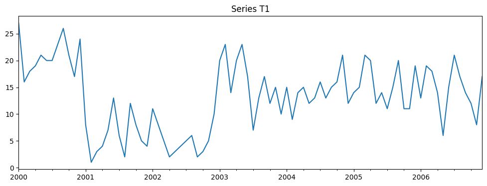

```python
df, _, _, _, _, = convert_tsf_to_dataframe("hospital_dataset.tsf")
vals = df.iloc[0]["series_value"]
idx = pd.date_range(start=df.iloc[0]["start_timestamp"], periods=len(vals), freq='ME')
ts1 = pd.Series(vals, index=idx)
ts1.plot(figsize=(12,4), title='Series T1')
plt.show()
```

In this plot we see the monthly patient counts for product "T1" for a period of seven years

```python
ts1.describe()
```

```
count    84.000000
mean     13.190476
std       6.378571
min       1.000000
25%       8.000000
50%      14.000000
75%      18.000000
max      27.000000
dtype: float64
```

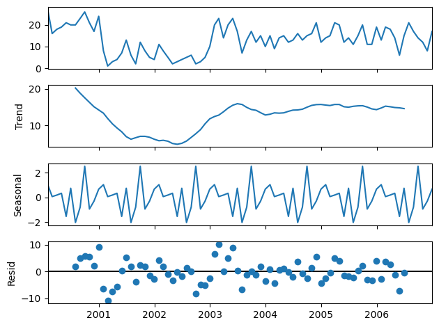

```python
# displaying trend, seasonality and residuals as well
result = seasonal_decompose(ts1, model='additive')
result.plot()
plt.show()
```

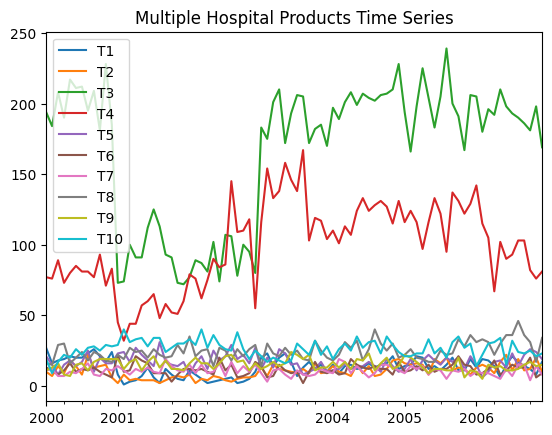

```python
for i in range(10):
    vals = df.iloc[i]["series_value"]
    idx = pd.date_range(start=df.iloc[i]["start_timestamp"], periods=len(vals), freq='ME')
    ts = pd.Series(vals, index=idx)
    ts.plot(label=df.iloc[i]["series_name"])

plt.legend()
plt.title("Multiple Hospital Products Time Series")
plt.show()
```

Over here we can see that the patient counts of one particular product are not independent. For example, "T3" and "T4" are clearly related and commonly used together.

### Ranking of months based on aggreagate product use

Now lets see out of the 12 years of the month, which months have the highest and lowest patient counts

```python
series = []
# converting to long format
for i in range(len(df)):
    series_id = df.iloc[i]["series_name"]
    values = df.iloc[i]["series_value"]
    start = df.iloc[i]["start_timestamp"]
    idx = pd.date_range(start=start, periods=len(values), freq='ME')

    tmp = pd.DataFrame({
        "series_id": series_id,
        "timestamp": idx,
        "value": values
    })
    series.append(tmp)

long_df = pd.concat(series, ignore_index=True)
long_df["month"] = long_df['timestamp'].dt.month
sum_per_month = long_df.groupby('month')['value'].sum()
ranked_months = sum_per_month.sort_values(ascending=False)
```

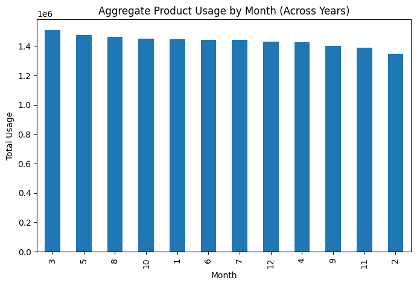

```python
sum_per_month.sort_values(ascending=False).plot(kind='bar', figsize=(8,5))
plt.xlabel("Month")
plt.ylabel("Total Usage")
plt.title("Aggregate Product Usage by Month (Across Years)")
plt.show()
```

It seems to be a mostly uniform distribution. March has the highest total usage and February has the lowest, which is contrary to my expectations, seeings as March follows February.

```python
mean_usage = sum_per_month.mean()
std_usage = sum_per_month.std()
threshold = 1.5 * std_usage
high_anomalies = sum_per_month[sum_per_month> mean_usage + threshold]
low_anomalies  = sum_per_month[sum_per_month < mean_usage - threshold]
```

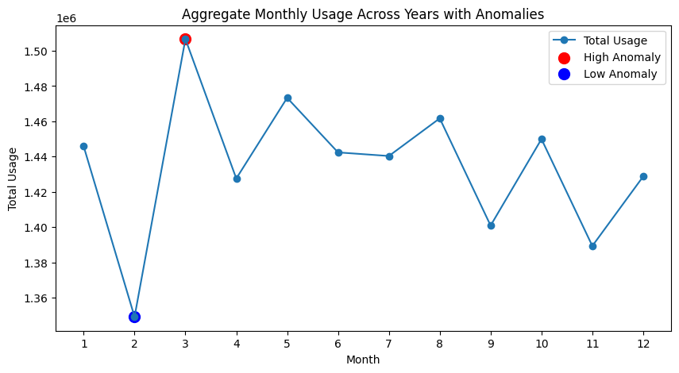

```python
plt.figure(figsize=(10,5))
plt.plot(sum_per_month.index, sum_per_month.values, marker='o', label='Total Usage')
plt.scatter(high_anomalies.index, high_anomalies.values, color='red', label='High Anomaly', s=100)
plt.scatter(low_anomalies.index, low_anomalies.values, color='blue', label='Low Anomaly', s=100)
plt.xticks(range(1,13))
plt.xlabel('Month')
plt.ylabel('Total Usage')
plt.title('Aggregate Monthly Usage Across Years with Anomalies')
plt.legend()
plt.show()
```

This graph makes it clear that february and march are outliers, as for why this is the case, my leading theory is that the jump from the low point in February to the high point in March is due to a recording quirk that causes some of the observations in February to be recorded as occuring in March instead. The fact that February is a month with an unusual amount of days, 28 or 29, could be the cause of this as well.

## Data Forecasting

Now, lets use Prophet to do bulk forecasting for all the series:

```python
from prophet import Prophet
forecasts = {}

for series_id, df_s in long_df.groupby('series_id'):
    # prepare dataframe for Prophet
    prophet_df = df_s[['timestamp','value']].rename(columns={'timestamp':'ds', 'value':'y'})

    # fit model
    m = Prophet(yearly_seasonality=True, daily_seasonality=False, weekly_seasonality=False)
    m.fit(prophet_df)

    # make future dataframe (next 12 months, for example)
    future = m.make_future_dataframe(periods=12, freq='ME')
    forecast = m.predict(future)

    # store forecast
    forecasts[series_id] = forecast[['ds','yhat','yhat_lower','yhat_upper']]
```

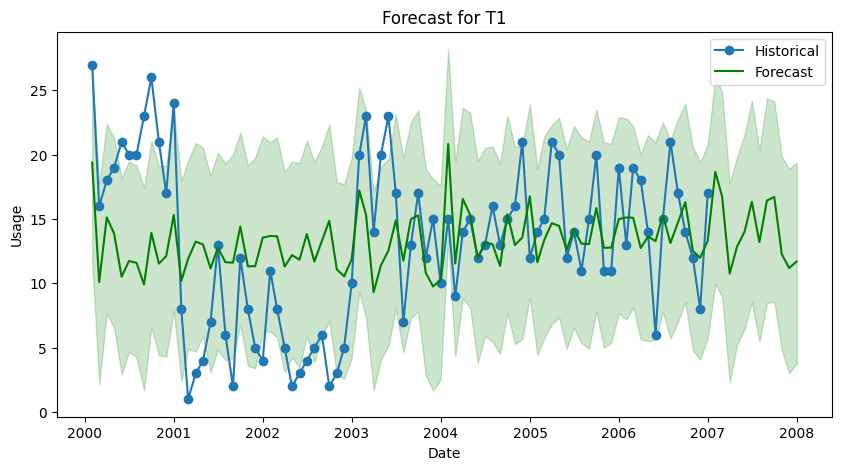

```python
# creating list for dropdown menu
series_options = list(forecasts.keys())
series_options = sorted(forecasts.keys(), key=lambda x: int(x[1:])) #sorting list numerically
#dropdown = widgets.Dropdown(
#    options=series_options,
#    description='Series:',
#    value=series_options[0]
#)


def plot_forecast(series_id):
    df_forecast = forecasts[series_id]
    # historical values for comparison
    df_hist = long_df[long_df['series_id']==series_id][['timestamp','value']].rename(columns={'timestamp':'ds','value':'y'})

    # plotting
    plt.figure(figsize=(10,5))
    plt.plot(df_hist['ds'], df_hist['y'], label='Historical', marker='o')
    plt.plot(df_forecast['ds'], df_forecast['yhat'], label='Forecast', color='green')
    plt.fill_between(df_forecast['ds'], df_forecast['yhat_lower'], df_forecast['yhat_upper'], color='green', alpha=0.2)
    plt.xlabel('Date')
    plt.ylabel('Usage')
    plt.title(f'Forecast for {series_id}')
    plt.legend()
    plt.show()

#widgets.interact(plot_forecast, series_id=dropdown)
chosen_series = series_options[0]
plot_forecast(chosen_series)
```